# Lecture 2: Linear Regression

## Resources

Here are some resources mentioned during the lecture:

- [Open data Toronto](https://open.toronto.ca/catalogue/?sort=last_refreshed%20desc)
- The free [R for Data science](https://r4ds.had.co.nz/) book
- [rvest](https://blog.rstudio.com/2014/11/24/rvest-easy-web-scraping-with-r/) package for web scraping
- [Environment Canada historical weather](https://climate.weather.gc.ca/historical_data/search_historic_data_e.html) page
- [tidyverse](https://www.tidyverse.org/) official page
- [tidymodels book](https://www.tmwr.org/)!

[figure not shown]

# Open Toronto Data

## About Bike Share Toronto Ridership Data

The [Bike Share Toronto Ridership data](https://open.toronto.ca/dataset/bike-share-toronto-ridership-data/) (2016-onwards) contains anonymized trip data, including:

- Trip start day and time
- Trip end day and time
- Trip duration
- Trip start station
- Trip end station
- User type

```r
# Load the required packages

# tidyverse for ingesting/cleaning/plotting data
library(tidyverse)

# lubridate for working with dates/timestamps
library(lubridate)

# rvest for scraping web data
library(rvest)

# read in the data
bike <- read_csv('Bikeshare Ridership (2017 Q1).csv')

# print a table of the first 6 observations
DT::datatable(head(bike), options = list(scrollX = T))
```

|  | trip_id | trip_start_time | trip_stop_time | trip_duration_seconds | from_station_id | from_station_name | to_station_id | to_station_name | user_type |
| --- | --- | --- | --- | --- | --- | --- | --- | --- | --- |
| 1 | 712382 | 1/1/2017 0:00 | 1/1/2017 0:03 | 223 | 7051 | Wellesley St E / Yonge St Green P | 7089 | Church St / Wood St | Member |
| 2 | 712383 | 1/1/2017 0:00 | 1/1/2017 0:05 | 279 | 7143 | Kendal Ave / Bernard Ave | 7154 | Bathurst Subway Station | Member |
| 3 | 712384 | 1/1/2017 0:05 | 1/1/2017 0:29 | 1394 | 7113 | Parliament St / Aberdeen Ave | 7199 | College St W / Markham St | Member |
| 4 | 712385 | 1/1/2017 0:07 | 1/1/2017 0:21 | 826 | 7077 | College Park South | 7010 | King St W / Spadina Ave | Member |
| 5 | 712386 | 1/1/2017 0:08 | 1/1/2017 0:12 | 279 | 7079 | McGill St / Church St | 7047 | University Ave / Gerrard St W | Member |
| 6 | 712387 | 1/1/2017 0:12 | 1/1/2017 0:22 | 571 | 7021 | Bay St / Albert St | 7046 | Niagara St / Richmond St W | Member |

## Question:

**Is the duration of a bike influenced by weather? For example, do Bike Share customers take longer bike rides in warmer weather?**

### Initial data exploration

```r
# number of observations and variables
cat("number of rows:", nrow(bike), "Number of columns:", ncol(bike), "\n")
```

```
## number of rows: 132123 Number of columns: 9
```

```r
# or we could print both at once
dim(bike)
```

```
## [1] 132123      9
```

```r
# a look at the data types
glimpse(bike)
```

```
## Observations: 132,123
## Variables: 9
## $ trip_id               <dbl> 712382, 712383, 712384, 712385, 712386, 71238...
## $ trip_start_time       <chr> "1/1/2017 0:00", "1/1/2017 0:00", "1/1/2017 0...
## $ trip_stop_time        <chr> "1/1/2017 0:03", "1/1/2017 0:05", "1/1/2017 0...
## $ trip_duration_seconds <dbl> 223, 279, 1394, 826, 279, 571, 1084, 307, 647...
## $ from_station_id       <dbl> 7051, 7143, 7113, 7077, 7079, 7021, 7161, 719...
## $ from_station_name     <chr> "Wellesley St E / Yonge St Green P", "Kendal ...
## $ to_station_id         <dbl> 7089, 7154, 7199, 7010, 7047, 7046, 7176, 703...
## $ to_station_name       <chr> "Church St  / Wood St", "Bathurst Subway Stat...
## $ user_type             <chr> "Member", "Member", "Member", "Member", "Memb...
```

```r
# is the trip_id unique
n_distinct(bike$trip_id) == nrow(bike)
```

```
## [1] TRUE
```

```r
# dates are character variables

# what is the format?

time_splits <- strsplit(bike$trip_start_time, "/")

# the first looks like day
table(as.numeric(sapply(time_splits, "[[", 1)))
```

```
##
##    1    2    3    4    5    6    7    8    9   10   11   12   13   14   15   16
## 4132 4418 4145 3031 2636 4958 3285 4392 5150 3586 3007 2765 3633 2870 3267 4865
##   17   18   19   20   21   22   23   24   25   26   27   28   29   30   31
## 4585 4096 4914 5309 5870 4998 6670 5541 4445 3419 6226 6130 3531 3644 2605
```

```r
# the second looks like month
table(as.numeric(sapply(time_splits, "[[", 2)))
```

```
##
##     1     2     3
## 41314 41626 49183
```

```r
# split the last section by the space
sub_time_split <- strsplit(sapply(time_splits, "[[", 3), " ")

# the third looks like year
table(as.numeric(sapply(sub_time_split, "[[", 1)))
```

```
##
##   2017
## 132123
```

```r
# split the remaining section by :

sub_time_split2 <- strsplit(sapply(sub_time_split, "[[", 2), ":")

# the fourth looks like hour
table(as.numeric(sapply(sub_time_split2, "[[", 1)))
```

```
##
##     0     1     2     3     4     5     6     7     8     9    10    11    12
##  6266  4713  3561  2647  1737  1034   614   492   237   292   650  2342  7229
##    13    14    15    16    17    18    19    20    21    22    23
## 13462  9579  5284  5735  6904  6467  6442  8650 12884 14920  9982
```

```r
# the fifth looks like minute
table(as.numeric(sapply(sub_time_split2, "[[", 2)))
```

```
##
##    0    1    2    3    4    5    6    7    8    9   10   11   12   13   14   15
## 2169 2115 2236 2228 2249 2308 2270 2348 2284 2273 2265 2311 2309 2192 2216 2144
##   16   17   18   19   20   21   22   23   24   25   26   27   28   29   30   31
## 2150 2245 2208 2268 2190 2114 2154 2100 2111 2115 2011 2123 2009 2026 2049 2111
##   32   33   34   35   36   37   38   39   40   41   42   43   44   45   46   47
## 2107 2031 2085 2112 2155 2218 2289 2174 2302 2292 2291 2237 2275 2219 2278 2252
##   48   49   50   51   52   53   54   55   56   57   58   59
## 2295 2307 2277 2257 2287 2223 2189 2156 2230 2271 2211 2202
```

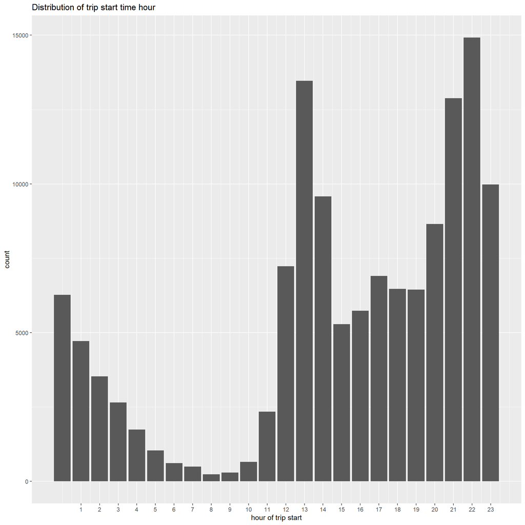

```r
# so the format is day/month/year hour:minute (we can use lubridate)

bike <- bike %>%
  mutate(trip_start_time = lubridate::dmy_hm(trip_start_time, tz = "America/New_York"),
         trip_stop_time = lubridate::dmy_hm(trip_stop_time, tz = "America/New_York"))

bike %>%
  count(hour = lubridate::hour(trip_start_time)) %>%
  ggplot(aes(hour, n)) +
  geom_bar(stat = "identity") +
  xlab("hour of trip start") +
  ylab("count") +
  ggtitle("Distribution of trip start time hour") +
  scale_x_continuous(breaks = 1:23)
```

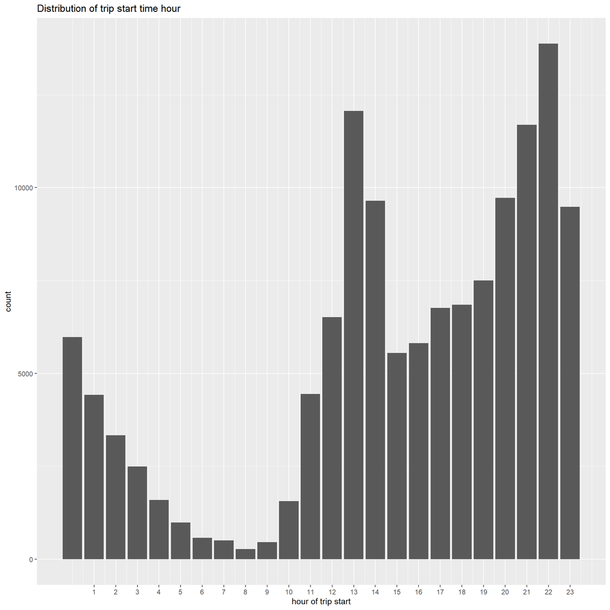

```r
# convert timestamps to easter
bike <- bike %>%
  mutate(trip_start_ts = lubridate::with_tz(trip_start_time, tzone = "EST"),
         trip_stop_ts = lubridate::with_tz(trip_stop_time, tzone = "EST"))

# that's what we expect!
bike %>%
  count(hour = lubridate::hour(trip_start_ts)) %>%
  ggplot(aes(hour, n)) +
  geom_bar(stat = "identity") +
  xlab("hour of trip start") +
  ylab("count") +
  ggtitle("Distribution of trip start time hour") +
  scale_x_continuous(breaks =1:23)
```

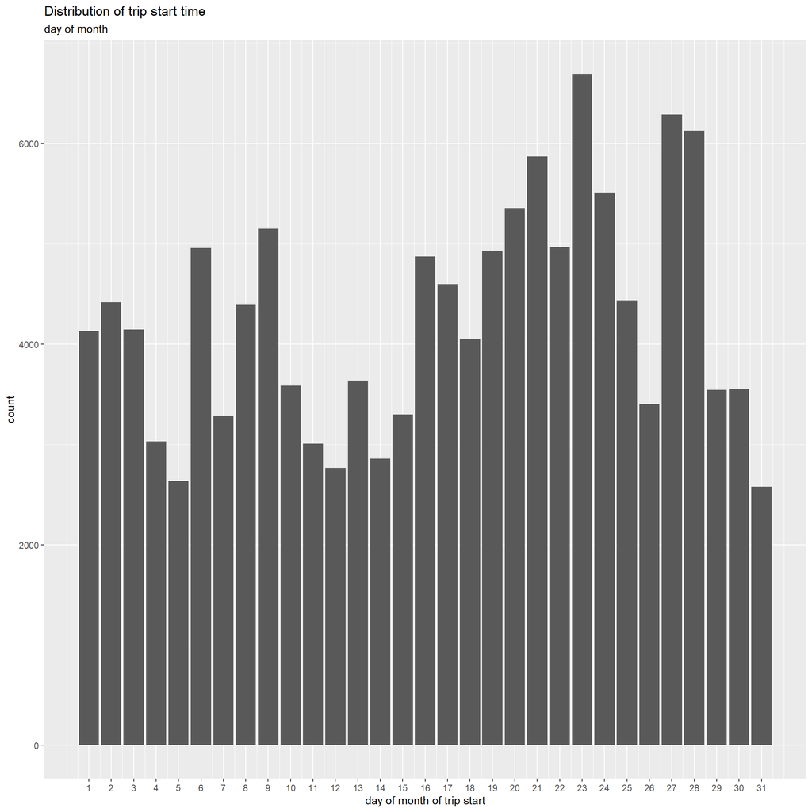

```r
# day of month

bike %>%
  count(day = lubridate::day(trip_start_ts)) %>%
  ggplot(aes(day, n)) +
  geom_bar(stat = "identity") +
  xlab("day of month of trip start") +
  ylab("count") +
  ggtitle("Distribution of trip start time",
          subtitle = "day of month") +
  scale_x_continuous(breaks =1:31)
```

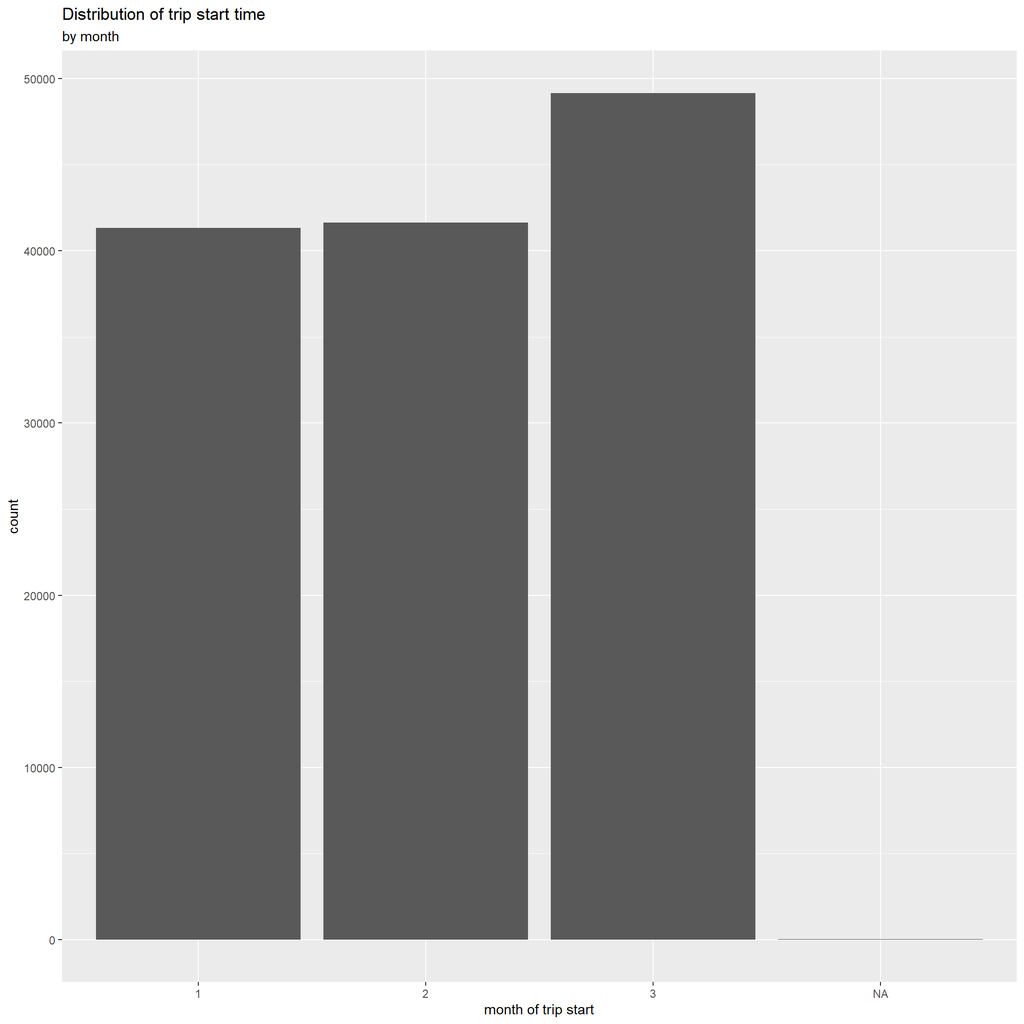

```r
# Month plot

bike %>%
  count(month = as_factor(lubridate::month(trip_start_ts))) %>%
  ggplot(aes(month, n)) +
  geom_bar(stat = "identity") +
  xlab("month of trip start") +
  ylab("count") +
  ggtitle("Distribution of trip start time",
          subtitle = "by month")
```

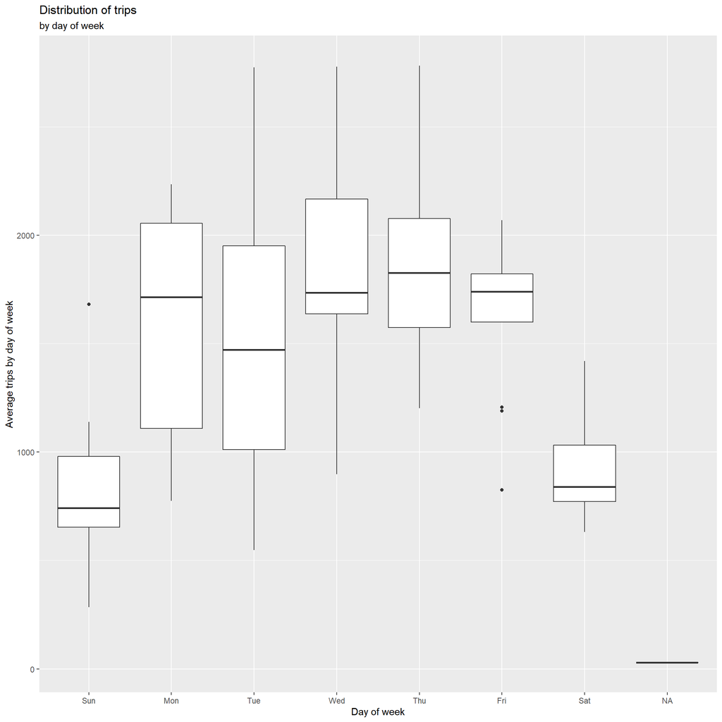

```r
# avg number of trips by day of week

bike %>%
  count(date = as_date(trip_start_ts)) %>%
  mutate(day_of_week = wday(date, label = T)) %>%
  ggplot(aes(day_of_week, n)) +
  geom_boxplot() +
  xlab("Day of week") +
  ylab("Average trips by day of week") +
  ggtitle("Distribution of trips",
          subtitle = "by day of week")
```

```r
## Create some additional features

bike <- bike %>%
  mutate_at(vars("trip_start_ts"), .funs = c(start_month = lubridate::month,
                                             start_day_of_week = lubridate::wday,
                                             start_day = lubridate::day,
                                             start_hr = lubridate::hour,
                                             start_min = lubridate::minute)) %>%
  mutate(date = as_date(trip_start_ts))

## Remove late 2016 values
bike <- bike %>% filter(year(date) == 2017)
```

## Adding in weather data

```r
clean_var_names <- function(x) {

  clean_x <- tolower(x) %>%
    str_replace_all(., "/|\'|°", "") %>%
    str_replace_all(., " ", "_")

  return(clean_x)
}





scrape_weather <- function(station = "51459",
                           year = 2017,
                           month = 3) {

  # the url to query
  query_url <- glue::glue('http://climate.weather.gc.ca/climate_data/daily_data_e.html?StationID={station}&timeframe=2&Year={year}&Month={month}#')

  # read in the table
  weather_data <- query_url %>%
    read_html() %>%
    html_table() %>%
    .[[1]]

  # clean up the names of the weather variables
  names(weather_data) <- clean_var_names(names(weather_data))

  # create dates and remove summary stats rows (i.e. where date is missing)
  weather_data <- weather_data %>%
    mutate(date = ymd(paste(year, month, day, '-'))) %>%
    select(date, mean_temp_definitionc, total_precip_definitionmm) %>%
    filter(!is.na(date))

  # transform weather variables to numeric
  # replace LegendTT with some small value
  weather_data <- weather_data %>%
    mutate(total_precip = as.numeric(ifelse(total_precip_definitionmm == "LegendTT",
                                            "0.01",total_precip_definitionmm)),
           total_precip = ifelse(is.na(total_precip), 0, total_precip),
           mean_temp = as.numeric(mean_temp_definitionc)) %>%
    select(date, mean_temp, total_precip)

  return(weather_data)

}
```

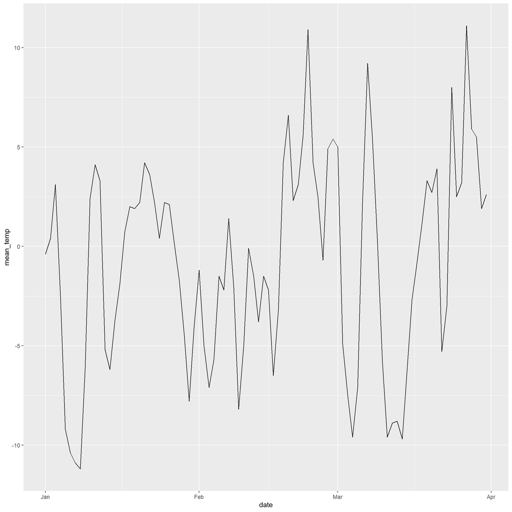

```r
# get weather for jan-march -----------------------------------------------
weather <- list()
months <- 1:3

for(i in months) {
  weather[[i]] <- scrape_weather(month = i)
}

weather <- do.call(rbind, weather)


# get a plot of the weather -----------------------------------------------
weather %>%
  ggplot(aes(date, mean_temp)) +
  geom_line()
```

```r
# join bike and weather data ----------------------------------------------

bike <- bike %>%
  left_join(weather, by = 'date')
```

```r
bike_daily <- bike %>%
  group_by(start_month, start_day, user_type) %>%
  summarize(trip_duration_seconds = mean(trip_duration_seconds),
            total_precip = mean(total_precip),
            mean_temp = mean(mean_temp)) %>%
  ungroup()

bike_daily <- bike_daily %>%
  mutate(log_duration = log(trip_duration_seconds),
         log_precip = log(total_precip + 1))
```

## Linear regression

A simple linear regression model takes the form:

$$Y = \beta_0 + \beta_1 x + \epsilon$$
- $\beta_0$ is the intercept term (The average value of Y when X = 0) - $\beta_1$ is called the slope (The amount Y increases with a 1 unit increase in X)

The error term really contains what we miss with this simple model:

- The true relationship is probably not linear,
- There may be other variables that cause variation in Y ,
- There may be measurement error. We typically assume that the error term is independent of X

An example linear regression model for our current example is:

$$y_i = \beta_0 + \beta_1 x_1 + \epsilon_i, i = 1,2, \dots, n$$

Where $Y_i$ is trip duration, $x_i$ is the temperature, $n$ is the number of observations, and $\epsilon ~ N(0, \sigma^2)$

### Linear Regression Statistical Assumptions

1. For any value of x, y is a $N(\beta_0 + \beta_1 x, \sigma^2)$
2. *Independence of errors*. The simple regression model assumes that the errors from the prediction line are independent.
3. *Linearity*: The mean value of $y$ is a linear function of $x$.
4. *Homoscedasticity*: The variance of $y$ is the same for any $x$.

## Estimating regression coefficients

Estimates of the regression coefficients $\beta_0$, $\beta_1$ are obtained by minimizing:

$$\sum_{i=1}^{n}\left( y_i - \left(\beta_0 + \beta_1 x_i\right) \right)^2$$

Using calculus there are closed form expressions for the minimizers: $\hat{\beta_0}$, $\hat{\beta_1}$:

The prediction for y based on the $i^\text{th}$ value of $x$ is:

$$\hat{y_i} = \hat{\beta_0} + \hat{\beta_1} x_i$$

$e_i = y_i - \hat{y_i}$, is the $i^\text{th}$ residual, and the residual sum of squares is:

$$RSS = \sum_{i=1}^{n} e_i^2$$

We could rewrite this as

$$RSS = (y_1 - \hat{\beta_0} - \hat{\beta_1} x_1)^2 + (y_2 - \hat{\beta_0} - \hat{\beta_1} x_2)^2 +\dots + (y_n - \hat{\beta_0} - \hat{\beta_1} x_n)^2$$

Using a little calculus we can show that:

$$\hat{\beta_1} = \frac{\sum_{i=1}^{n}\left(x_i -\bar{x} \right)\left(y_i -\bar{y} \right) }{\sum_{i=1}^{n}\left(x_i -\bar{x} \right)^2}$$

and

$$\hat{\beta_0} = \bar{y} - \hat{\beta_1}\bar{x}$$

## Accuracy of regression coefficients

The accuracy of the regression coefficients can be evaluated by computing the standard errors of $\hat{\beta_0}$, $\hat{\beta_1}$.

$\sigma^2$ can be estimated by the formula:

$$\sqrt{\frac{1}{n-2}RSS} = \sqrt{\frac{1}{n-2}\sum_{i=1}^{n}(y_i - \hat{y_i})^2}$$

$$RSE = \frac{RSS}{n - 2}$$

Standard errors can be used to test:

$$H_0:\text{There is no linear relationship between x and y}$$
$$H_1:\text{There is a linear relationship between x and y}$$

Which corresponds to testing:

$$H_0: \beta_1 = 0 \text{ vs } H1: \beta_1 \neq 0$$

Tests and confidence intervals are based on:

$$\frac{\hat{\beta_1}}{SE \left(\hat{\beta_1} \right) } \sim t_{n-2}$$

where:

$$SE(\hat{\beta_1})^2 = \frac{\sigma^2}{\sum_{i=1}^{n}(x_i-\bar{x})^2}$$

## Accuracy of Model

The proportion of variability in $y$ that can be explained by linear regression model of $y$ on x.

$$R^2 = \frac{TSS - RSS}{TSS} = 1 - \frac{RSS}{TSS}$$

Where TSS is the true sum of squares: $\sum(y_i-\bar{y})^2$ and RSS is the residual sum of squares: $\sum(y_i - \hat{y_i})^2$

### Example with Simulated data

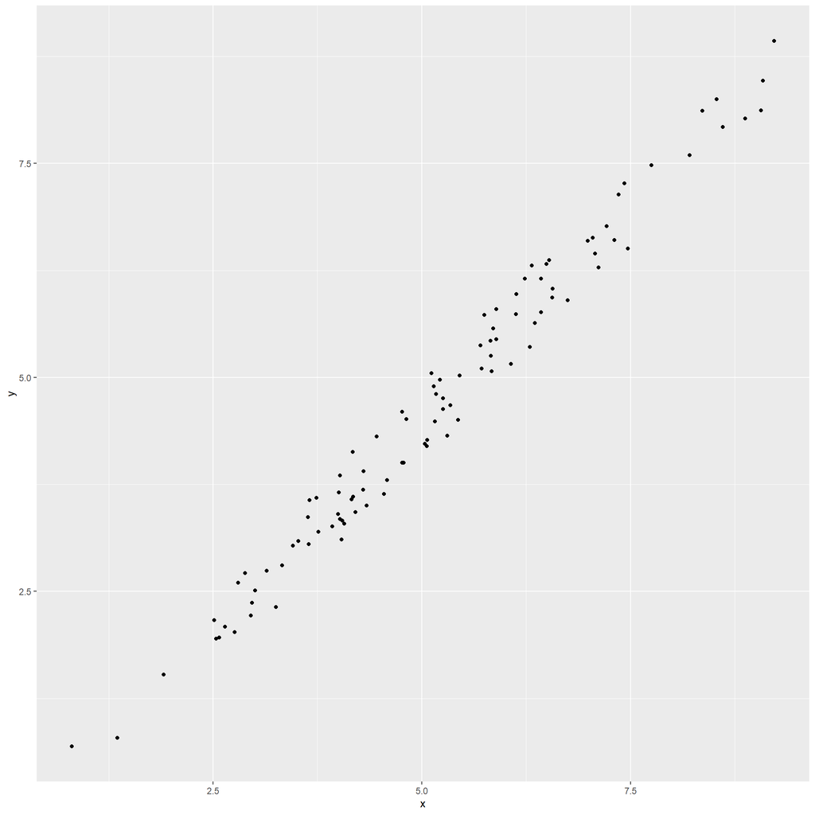

```r
set.seed(2552)

# draw 100 samples from N(5,4)
y <-  rnorm(100, 5, 2)

x <- y + runif(100, 0,1)

fake_data <- tibble(x, y)

fake_data %>%
  ggplot(aes( x, y)) +
  geom_point()
```

```r
model <- lm(y ~ x, data = fake_data)

summary(model)
```

```
##
## Call:
## lm(formula = y ~ x, data = fake_data)
##
## Residuals:
##      Min       1Q   Median       3Q      Max
## -0.47897 -0.20892 -0.06553  0.24070  0.50273
##
## Coefficients:
##             Estimate Std. Error t value Pr(>|t|)
## (Intercept) -0.47400    0.08189  -5.788 8.57e-08 ***
## x            0.99327    0.01492  66.570  < 2e-16 ***
## ---
## Signif. codes:  0 '***' 0.001 '**' 0.01 '*' 0.05 '.' 0.1 ' ' 1
##
## Residual standard error: 0.2677 on 98 degrees of freedom
## Multiple R-squared:  0.9784, Adjusted R-squared:  0.9781
## F-statistic:  4432 on 1 and 98 DF,  p-value: < 2.2e-16
```

A prettier printing method than the raw `summary()` function.

```r
library(pander)

pander( summary(model) )
```

|  | Estimate | Std. Error | t value | Pr(>\|t\|) |
| --- | --- | --- | --- | --- |
| **(Intercept)** | -0.474 | 0.08189 | -5.788 | 8.57e-08 |
| **x** | 0.9933 | 0.01492 | 66.57 | 2.153e-83 |

Fitting linear model: y ~ x

| Observations | Residual Std. Error | $R^2$ | Adjusted $R^2$ |
| --- | --- | --- | --- |
| 100 | 0.2677 | 0.9784 | 0.9781 |

below is a plot of the line of best fit

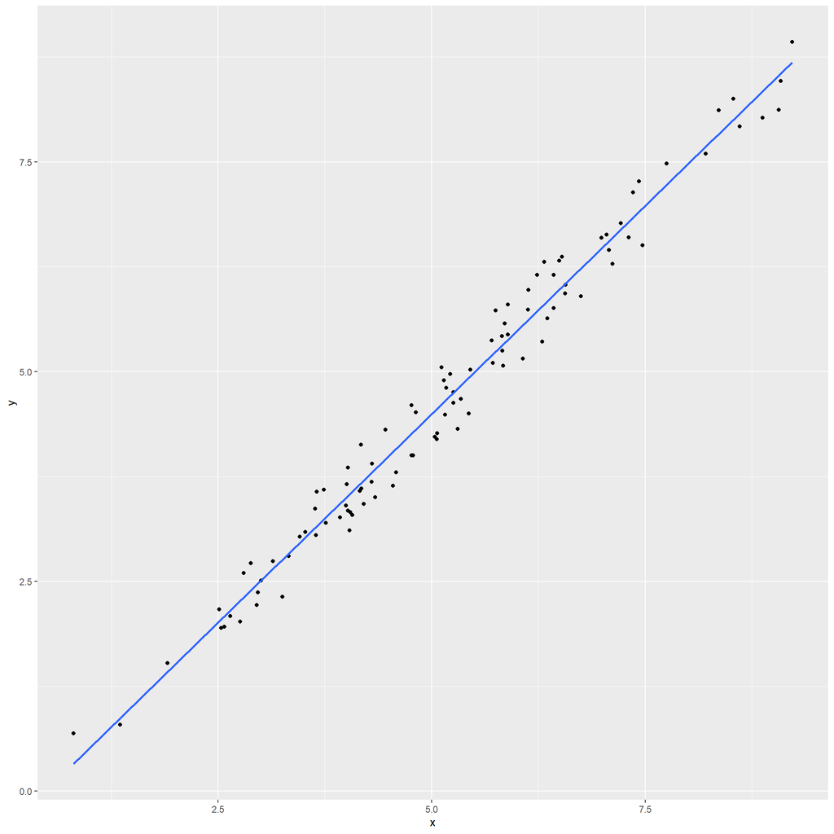

```r
fake_data %>%
  ggplot(aes(x, y)) +
  geom_point() +
  geom_smooth(method='lm', formula= y~x, se = F)
```

## Linear regression with the Bike share data

### Preparing the data for analysis

```r
bike_daily <- bike %>%
  group_by(start_month, start_day, user_type) %>%
  summarize(trip_duration_seconds = mean(trip_duration_seconds),
            total_precip = mean(total_precip),
            mean_temp = mean(mean_temp))

bike_daily <- bike_daily %>%
  mutate(log_duration = log(trip_duration_seconds),
         log_precip = log(total_precip + 1))
```

```r
model <- lm(trip_duration_seconds~ mean_temp, data = bike_daily)
pander( summary(model) )
```

|  | Estimate | Std. Error | t value | Pr(>\|t\|) |
| --- | --- | --- | --- | --- |
| **(Intercept)** | 1058 | 43.38 | 24.39 | 1.227e-58 |
| **mean_temp** | 8.435 | 8.229 | 1.025 | 0.3068 |

Fitting linear model: trip_duration_seconds ~ mean_temp

| Observations | Residual Std. Error | $R^2$ | Adjusted $R^2$ |
| --- | --- | --- | --- |
| 180 | 575 | 0.005868 | 0.0002827 |

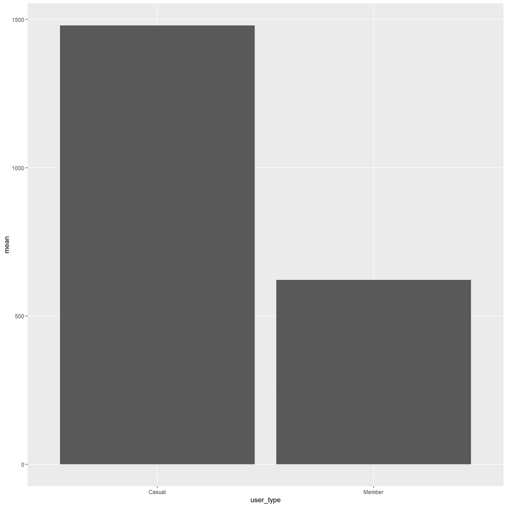

```r
bike_daily %>%
  group_by(user_type) %>%
  summarize(mean = mean(trip_duration_seconds)) %>%
  ggplot(aes(user_type, mean)) + geom_bar(stat = 'identity')
```

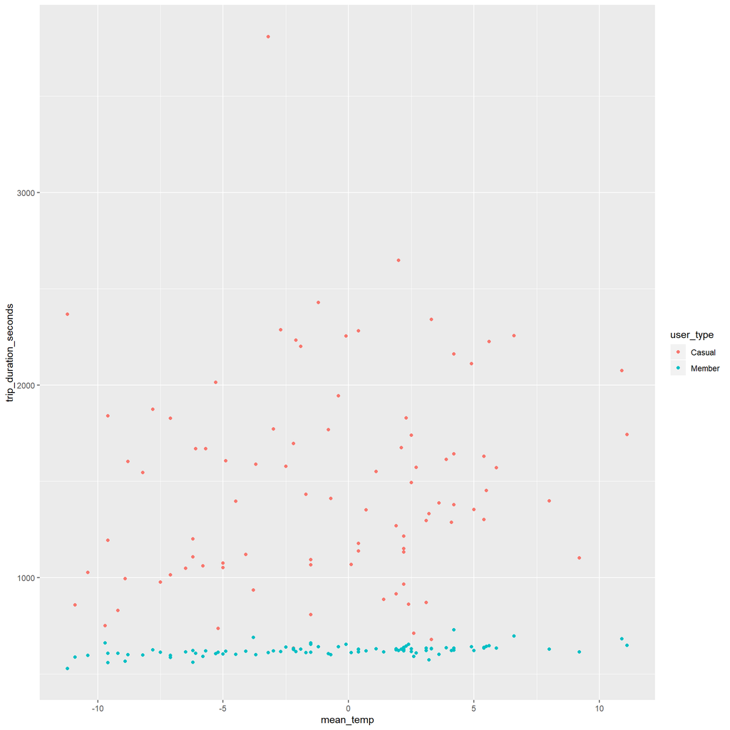

```r
bike_daily %>%
  ggplot(aes(mean_temp, trip_duration_seconds, color = user_type)) +
  geom_point()
```

### How do we interpret a qualitative predictor/feature?

```r
model <- lm(trip_duration_seconds~ user_type, data = bike_daily)
pander( summary(model) )
```

|  | Estimate | Std. Error | t value | Pr(>\|t\|) |
| --- | --- | --- | --- | --- |
| **(Intercept)** | 1480 | 40.28 | 36.75 | 4.822e-85 |
| **user_typeMember** | -859 | 56.97 | -15.08 | 1.222e-33 |

Fitting linear model: trip_duration_seconds ~ user_type

| Observations | Residual Std. Error | $R^2$ | Adjusted $R^2$ |
| --- | --- | --- | --- |
| 180 | 382.1 | 0.5609 | 0.5584 |

$$x_i =
\begin{cases}
1,& \text{ if the } i^\text{th}\text{ person is a member} \\
0,& \text{ if the } i^\text{th}\text{ person is casual}
\end{cases}$$

$$y_i = \beta_0 + \beta_1 x + \epsilon_i =
\begin{cases}
\beta_0 + \beta_1 x_i + \epsilon_i &\text{ if the } i^\text{th}\text{ person is a member} \\
\beta_0 + \epsilon_i &\text{ if the } i^\text{th}\text{ person is casual}
\end{cases}$$

```r
bike_daily %>%
  group_by(user_type) %>%
  summarize(mean_duration = mean(trip_duration_seconds)) %>%
  mutate(difference = mean_duration - lag(mean_duration))
```

| user_type | mean_duration | difference |
| --- | --- | --- |
| Casual | 1480.4814 | NA |
| Member | 621.4606 | -859.0209 |

```r
t.test(bike_daily$trip_duration_seconds ~ bike_daily$user_type)
```

```
##
##  Welch Two Sample t-test
##
## data:  bike_daily$trip_duration_seconds by bike_daily$user_type
## t = 15.079, df = 89.487, p-value < 2.2e-16
## alternative hypothesis: true difference in means is not equal to 0
## 95 percent confidence interval:
##  745.8368 972.2049
## sample estimates:
## mean in group Casual mean in group Member
##            1480.4814             621.4606
```

## Adjusting for more than one feature/predictor

### Multiple Linear Regression

Do temperature and user type predict trip duration?

For $p$ potential covariates we have

$$y_i = \beta_0 + \beta_1 x_{i1} + \beta_2 x_{i2} + \dots + \beta_p x_{ip} + \epsilon_i, i = 1\dots n$$

In matrix form:

$$Y = X\beta + \epsilon$$

$Y$ is an $n\times1$ column vector, $X$ is an $n\times p$ matrix of rank $p$, and $\epsilon$ is an $n\times1$ column vector that has a multivariate normal distribution.

```r
model <- lm(trip_duration_seconds~ mean_temp + user_type, data = bike_daily)
pander( summary(model) )
```

|  | Estimate | Std. Error | t value | Pr(>\|t\|) |
| --- | --- | --- | --- | --- |
| **(Intercept)** | 1487 | 40.37 | 36.84 | 6.199e-85 |
| **mean_temp** | 8.435 | 5.448 | 1.548 | 0.1233 |
| **user_typeMember** | -859 | 56.74 | -15.14 | 9.439e-34 |

Fitting linear model: trip_duration_seconds ~ mean_temp + user_type

| Observations | Residual Std. Error | $R^2$ | Adjusted $R^2$ |
| --- | --- | --- | --- |
| 180 | 380.7 | 0.5668 | 0.5619 |

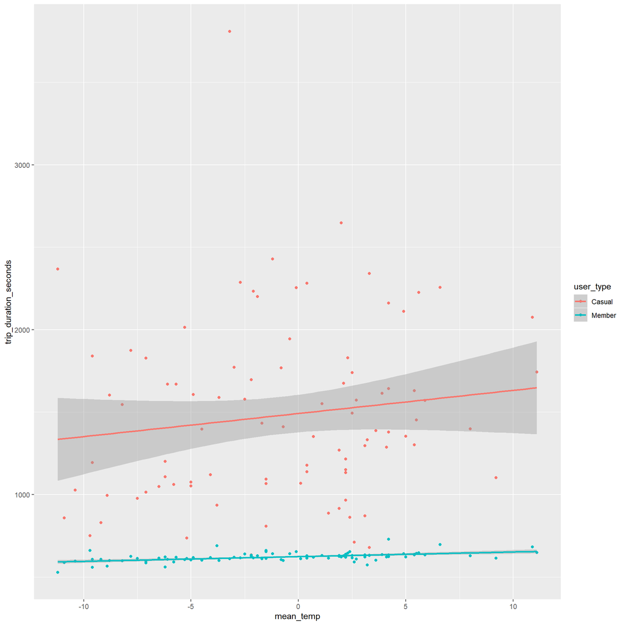

```r
bike_daily %>%
  ggplot(aes(mean_temp, trip_duration_seconds, color = user_type))+
  geom_point() +
  geom_smooth(method = "lm")
```

```r
model <- lm(trip_duration_seconds~ mean_temp + user_type + mean_temp*user_type, data = bike_daily)
pander( summary(model) )
```

|  | Estimate | Std. Error | t value | Pr(>\|t\|) |
| --- | --- | --- | --- | --- |
| **(Intercept)** | 1492 | 40.61 | 36.74 | 1.817e-84 |
| **mean_temp** | 14.03 | 7.703 | 1.821 | 0.07023 |
| **user_typeMember** | -868.1 | 57.43 | -15.12 | 1.239e-33 |
| **mean_temp:user_typeMember** | -11.19 | 10.89 | -1.027 | 0.3057 |

Fitting linear model: trip_duration_seconds ~ mean_temp + user_type + mean_temp * user_type

| Observations | Residual Std. Error | $R^2$ | Adjusted $R^2$ |
| --- | --- | --- | --- |
| 180 | 380.6 | 0.5694 | 0.562 |

## Variable selection

How do we select which variables are entered into the linear regression?

If we have $p$ potential covariates under consideration, then there are $2^p$ potential models under we could consider. Trying to fit all potential submodels isn’t feasible, so practitioners have come up with a few algorithms for determining which variables to include. Here are three (there are many more)

- Forward Selection
- Backward Selection
- Mixed selection: This is a combination of the previous 2 algorithms. P-values change as we add variables with forward selection (they get larger). We can remove features whos p-values cross a certain threshold.

## Linear regression as a machine learning algorithm

```r
# regression --------------------------------------------------------------

library(tidymodels)
# resample functions
# Make sure that you get the same random numbers
set.seed(4595)
data_split <- initial_split(bike_daily, prop = .80)

bike_train <- training(data_split)
bike_test  <- testing(data_split)

nrow(bike_train)/nrow(bike_daily)
```

```
## [1] 0.8055556
```

```r
training(data_split)
```

| start_month | start_day | user_type | trip_duration_seconds | total_precip | mean_temp | log_duration | log_precip |
| --- | --- | --- | --- | --- | --- | --- | --- |
| 1 | 1 | Member | 640.1439 | 0.00 | -0.4 | 6.461693 | 0.000000000 |
| 1 | 2 | Casual | 2281.6333 | 0.01 | 0.4 | 7.732647 | 0.009950331 |
| 1 | 2 | Member | 627.7781 | 0.01 | 0.4 | 6.442187 | 0.009950331 |
| 1 | 3 | Casual | 871.6000 | 15.80 | 3.1 | 6.770331 | 2.821378886 |
| 1 | 3 | Member | 634.3830 | 15.80 | 3.1 | 6.452653 | 2.821378886 |
| 1 | 4 | Member | 638.5764 | 0.20 | -2.5 | 6.459241 | 0.182321557 |
| 1 | 5 | Casual | 828.6500 | 0.01 | -9.2 | 6.719798 | 0.009950331 |
| 1 | 5 | Member | 607.5880 | 0.01 | -9.2 | 6.409497 | 0.009950331 |
| 1 | 6 | Casual | 1027.5294 | 0.00 | -10.4 | 6.934913 | 0.000000000 |
| 1 | 6 | Member | 596.6978 | 0.00 | -10.4 | 6.391411 | 0.000000000 |

[output cut: 135 more lines]

```r
# ------------------------------------------------------------------------------
# A Linear Regression Model

simple_lm <- lm(trip_duration_seconds~ mean_temp + total_precip + user_type, data = bike_train)

simple_lm_values <- augment(simple_lm)
names(simple_lm_values)
```

```
##  [1] "trip_duration_seconds" "mean_temp"             "total_precip"
##  [4] "user_type"             ".fitted"               ".se.fit"
##  [7] ".resid"                ".hat"                  ".sigma"
## [10] ".cooksd"               ".std.resid"
```

```r
# using parsnip -----------------------------------------------------------
spec_lin_reg <- linear_reg()
spec_lin_reg
```

```
## Linear Regression Model Specification (regression)
```

```r
lm_mod <- set_engine(spec_lin_reg, "lm")
lm_mod
```

```
## Linear Regression Model Specification (regression)
##
## Computational engine: lm
```

```r
lm_fit <- fit(
  lm_mod,
  trip_duration_seconds~ mean_temp + total_precip + user_type,
  data = bike_train
)


fit_xy(
  lm_mod,
  y = bike_train$trip_duration_seconds,
  x = bike_train %>% dplyr::select(mean_temp, total_precip, user_type)
)
```

[output not shown]

```r
# ------------------------------------------------------------------------------
# Predictions

# Numeric predictions always in a df
# with column `.pred`

test_pred <-
  lm_fit %>%
  predict(bike_test) %>%
  bind_cols(bike_test)

test_pred %>%
  dplyr::select(trip_duration_seconds, .pred) %>%
  slice(1:3)
```

| trip_duration_seconds | .pred |
| --- | --- |
| 1943.6623 | 1485.704 |
| 1577.6216 | 1450.258 |
| 735.4286 | 1413.343 |

```r
# ------------------------------------------------------------------------------
# Estimating Performance

# yardstick loaded by tidymodels

perf_metrics <- metric_set(rmse, rsq)

# A tidy result back:
test_pred  %>%
  perf_metrics(truth = trip_duration_seconds, estimate = .pred)
```

| .metric | .estimator | .estimate |
| --- | --- | --- |
| rmse | standard | 359.2428418 |
| rsq | standard | 0.7144084 |